# Red Wines Exploration by Natalia Lokshina

This report explores a dataset containing properties of almost 1,600 red wines.

# Univariate Plots Section

First we need to look at some summaries of the data in order to get the idea of the data structure.

```
## 'data.frame':    1599 obs. of  13 variables:
##  $ X                   : int  1 2 3 4 5 6 7 8 9 10 ...
##  $ fixed.acidity       : num  7.4 7.8 7.8 11.2 7.4 7.4 7.9 7.3 7.8 7.5 ...
##  $ volatile.acidity    : num  0.7 0.88 0.76 0.28 0.7 0.66 0.6 0.65 0.58 0.5 ...
##  $ citric.acid         : num  0 0 0.04 0.56 0 0 0.06 0 0.02 0.36 ...
##  $ residual.sugar      : num  1.9 2.6 2.3 1.9 1.9 1.8 1.6 1.2 2 6.1 ...
##  $ chlorides           : num  0.076 0.098 0.092 0.075 0.076 0.075 0.069 0.065 0.073 0.071 ...
##  $ free.sulfur.dioxide : num  11 25 15 17 11 13 15 15 9 17 ...
##  $ total.sulfur.dioxide: num  34 67 54 60 34 40 59 21 18 102 ...
##  $ density             : num  0.998 0.997 0.997 0.998 0.998 ...
##  $ pH                  : num  3.51 3.2 3.26 3.16 3.51 3.51 3.3 3.39 3.36 3.35 ...
##  $ sulphates           : num  0.56 0.68 0.65 0.58 0.56 0.56 0.46 0.47 0.57 0.8 ...
##  $ alcohol             : num  9.4 9.8 9.8 9.8 9.4 9.4 9.4 10 9.5 10.5 ...
##  $ quality             : int  5 5 5 6 5 5 5 7 7 5 ...
```

```
##        X          fixed.acidity   volatile.acidity  citric.acid
##  Min.   :   1.0   Min.   : 4.60   Min.   :0.1200   Min.   :0.000
##  1st Qu.: 400.5   1st Qu.: 7.10   1st Qu.:0.3900   1st Qu.:0.090
##  Median : 800.0   Median : 7.90   Median :0.5200   Median :0.260
##  Mean   : 800.0   Mean   : 8.32   Mean   :0.5278   Mean   :0.271
##  3rd Qu.:1199.5   3rd Qu.: 9.20   3rd Qu.:0.6400   3rd Qu.:0.420
##  Max.   :1599.0   Max.   :15.90   Max.   :1.5800   Max.   :1.000
##  residual.sugar     chlorides       free.sulfur.dioxide
##  Min.   : 0.900   Min.   :0.01200   Min.   : 1.00
##  1st Qu.: 1.900   1st Qu.:0.07000   1st Qu.: 7.00
##  Median : 2.200   Median :0.07900   Median :14.00
##  Mean   : 2.539   Mean   :0.08747   Mean   :15.87
##  3rd Qu.: 2.600   3rd Qu.:0.09000   3rd Qu.:21.00
##  Max.   :15.500   Max.   :0.61100   Max.   :72.00
##  total.sulfur.dioxide    density             pH          sulphates
##  Min.   :  6.00       Min.   :0.9901   Min.   :2.740   Min.   :0.3300
##  1st Qu.: 22.00       1st Qu.:0.9956   1st Qu.:3.210   1st Qu.:0.5500
##  Median : 38.00       Median :0.9968   Median :3.310   Median :0.6200
##  Mean   : 46.47       Mean   :0.9967   Mean   :3.311   Mean   :0.6581
##  3rd Qu.: 62.00       3rd Qu.:0.9978   3rd Qu.:3.400   3rd Qu.:0.7300
##  Max.   :289.00       Max.   :1.0037   Max.   :4.010   Max.   :2.0000
##     alcohol         quality
##  Min.   : 8.40   Min.   :3.000
##  1st Qu.: 9.50   1st Qu.:5.000
##  Median :10.20   Median :6.000
##  Mean   :10.42   Mean   :5.636
##  3rd Qu.:11.10   3rd Qu.:6.000
##  Max.   :14.90   Max.   :8.000
```

Our dataset contains 1,599 observations of red wines with 11 variables on the chemical properties of the wine and 1 variable on quality. At least 3 wine experts rated the quality of each wine, providing a rating between 0 (very bad) and 10 (very excellent).

Lets look at the distribution of the individual variables.

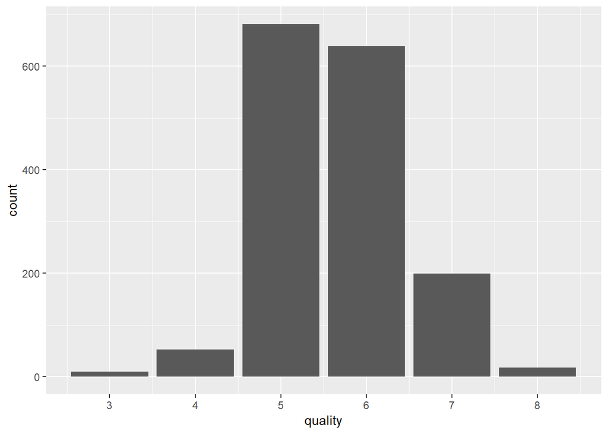

From this bar plot we can see, that more than half of the wines in our dataset got quality rating 5 or 6. None of the wines were rated lower than 3 and higher than 8.

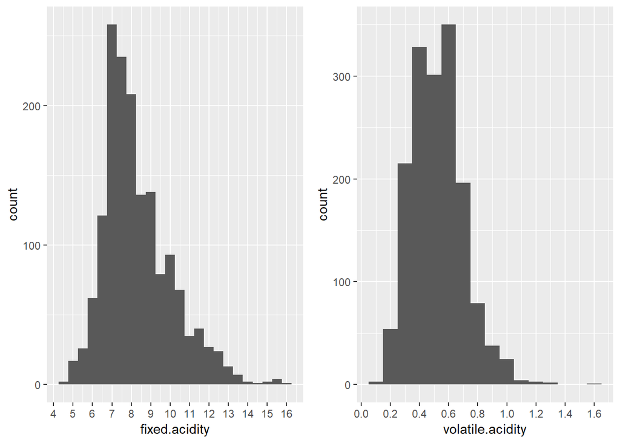

The distributions of the fixed acidity and volatile acidity are right skewed. They both have a noticeable pick: fixed acidity somewhere between 6.5 and 8.5 and volatile acidity between 0.3 and 0.7. Since the distributions look similar, it will be interesting to see if these variables are correlated.

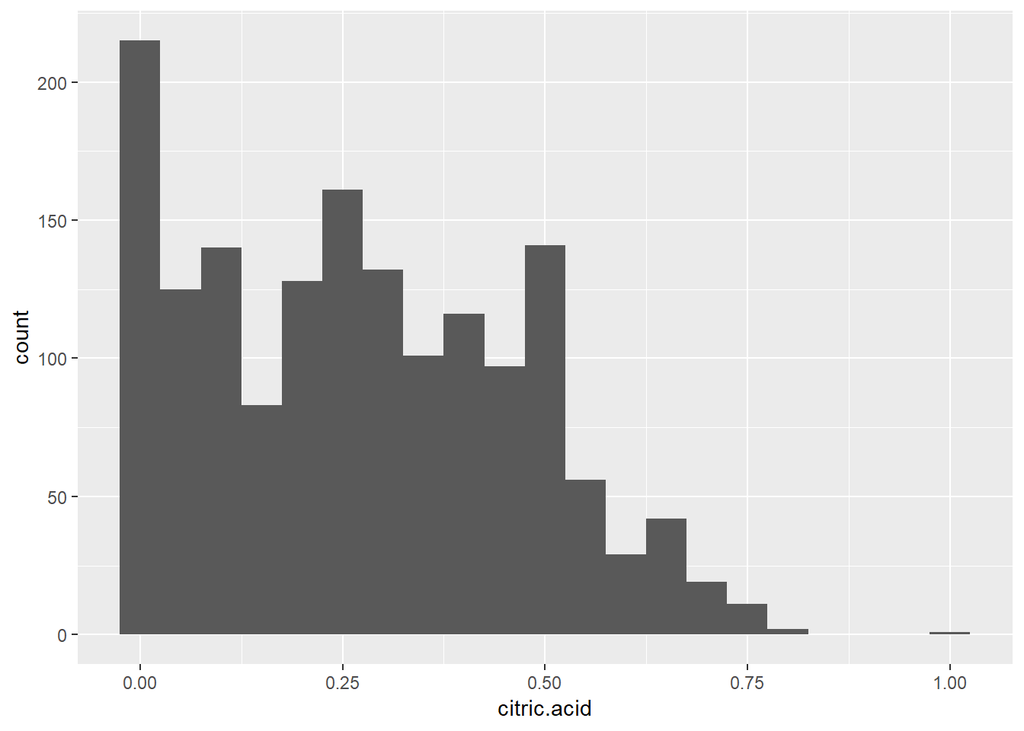

```r
# calculate the amount of values = 1, 0 and < 0.05 (1st bin)
print(dim(df[df$citric.acid == 1,]))
```

```
## [1]  1 13
```

```r
print(dim(df[df$citric.acid == 0,]))
```

```
## [1] 132  13
```

```r
print(dim(df[df$citric.acid < 0.05,]))
```

```
## [1] 274  13
```

The citric acid distribution looks multimodal with the biggest pick close to 0 and the other 2 about 0.25 and 0.5. There is one outlier with the value 1. Also out of 274 values less then 0.05, which fall into the first bin, almost half (132) have value 0. I wonder if they represent missing data and not the actual level of citric acid.

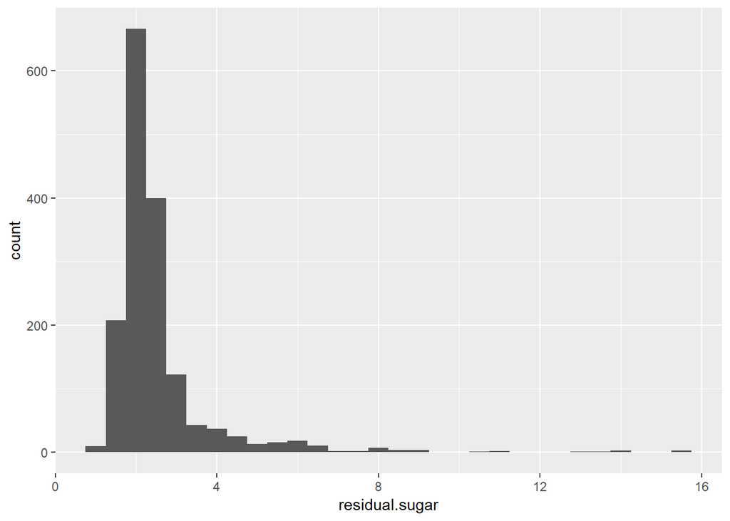

On the residual sugar histogram we can see a few outliers which give the distribution a big right skew. Let’s zoom in.

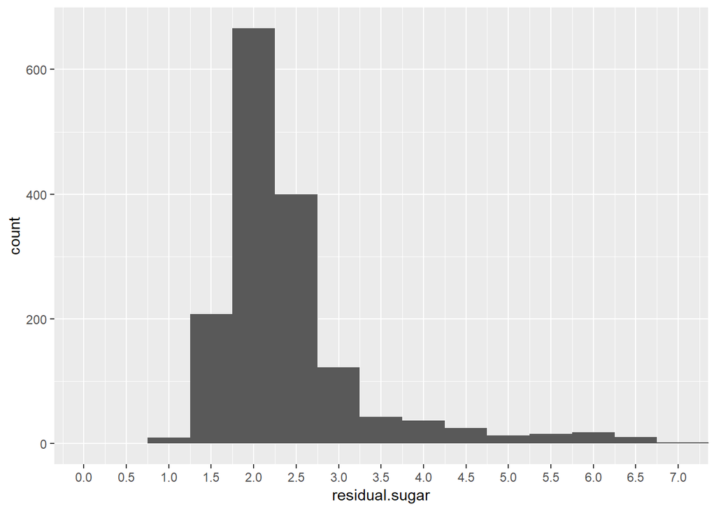

```
##    Min. 1st Qu.  Median    Mean 3rd Qu.    Max.
##   0.900   1.900   2.200   2.539   2.600  15.500
```

From the histogram and the statistics we can tell that half of the values are between 1.9 and 2.6. Interesting to note that the mean (2.539) is very close to 3rd quartile (2.6), which explains a long right skew.

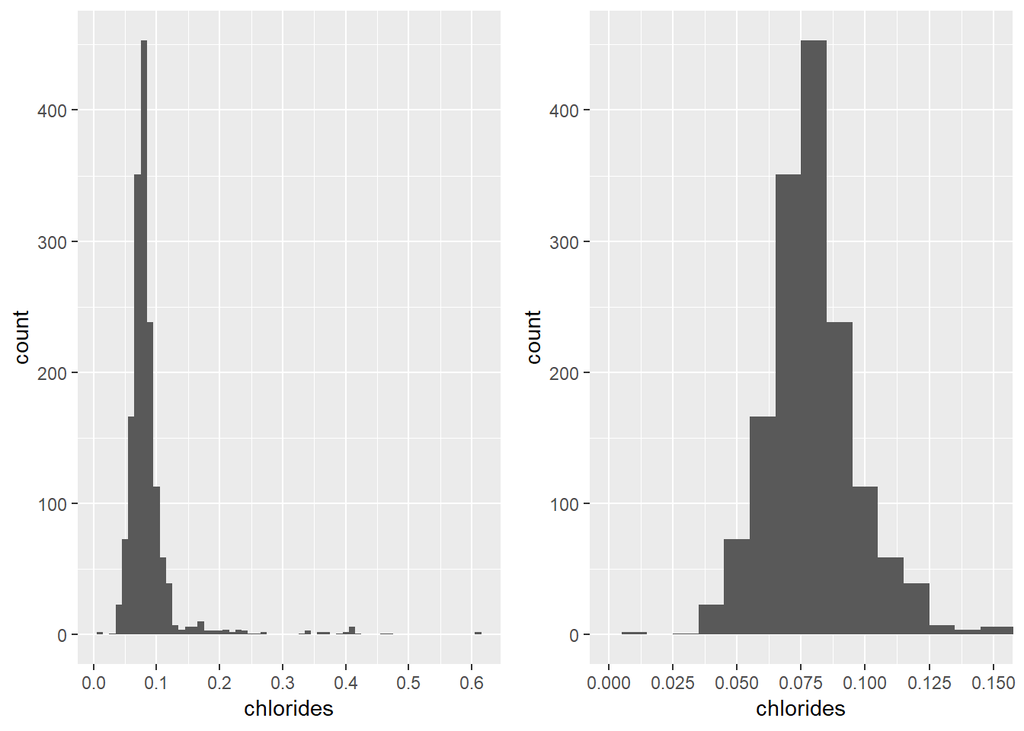

```
##    Min. 1st Qu.  Median    Mean 3rd Qu.    Max.
## 0.01200 0.07000 0.07900 0.08747 0.09000 0.61100
```

The distribution of chlorides is similar to residual sugar. 50% of values are between 0.07 and 0.09.

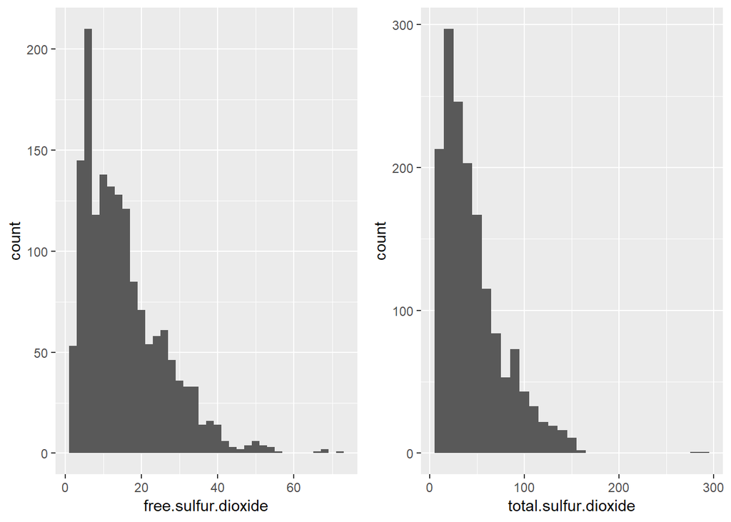

```
##    Min. 1st Qu.  Median    Mean 3rd Qu.    Max.
##    1.00    7.00   14.00   15.87   21.00   72.00
```

```
##    Min. 1st Qu.  Median    Mean 3rd Qu.    Max.
##    6.00   22.00   38.00   46.47   62.00  289.00
```

The distributions of free sulfur dioxide and total sulfur dioxide also look very similar. They are both right skewed. The free sulfur dioxide values lie between 1 and 72 with half of them between 7 and 21 and median 14. The total sulfur dioxide values have minimum of 6 and maximum of 289. There are few outliers close to 289, but 75% of the values are less than 62. I would expect these two variables to be correlated.

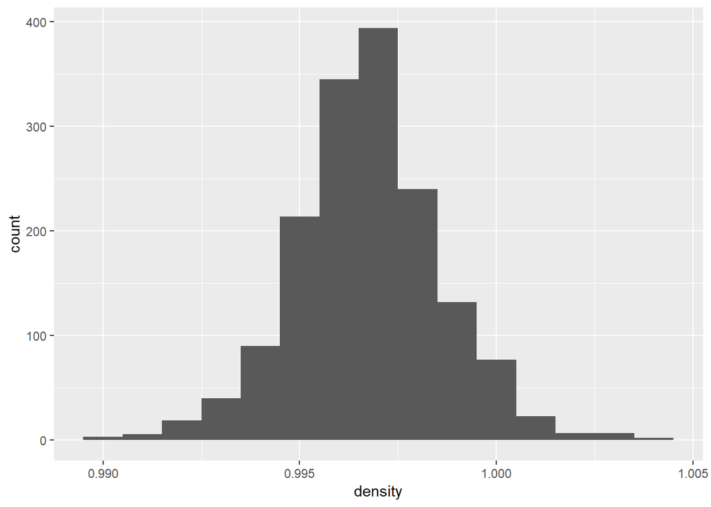

```
##    Min. 1st Qu.  Median    Mean 3rd Qu.    Max.
##  0.9901  0.9956  0.9968  0.9967  0.9978  1.0037
```

Density looks normally distributed. The mean and median are almost identical: 0.9967 and0.9968. Interesting to note that all values lie in a very small range: 0.0136. Interquartile range is just 0.0022.

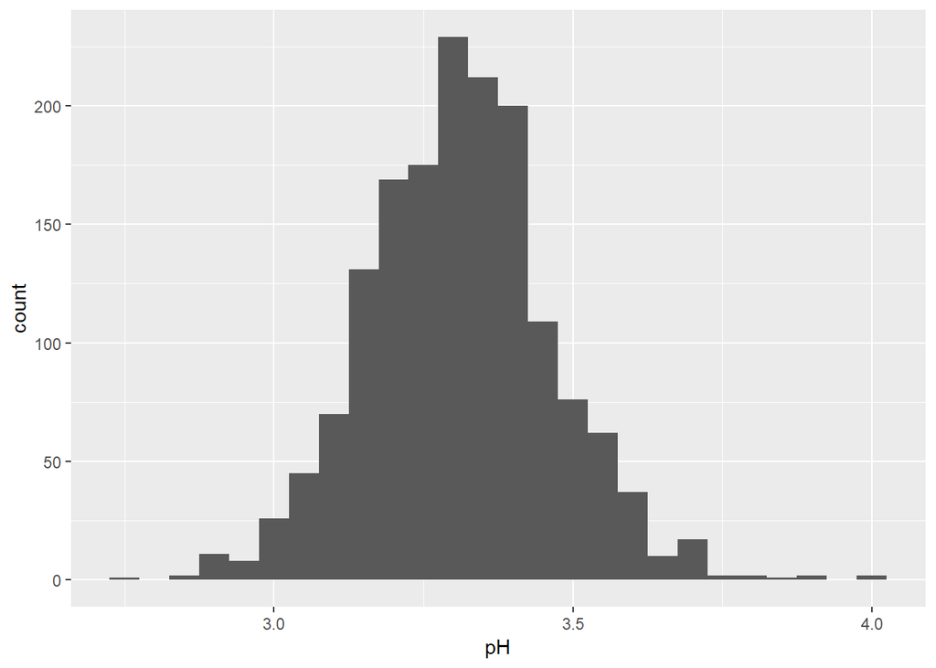

```
##    Min. 1st Qu.  Median    Mean 3rd Qu.    Max.
##   2.740   3.210   3.310   3.311   3.400   4.010
```

The distribution of pH is also close to normal with mean = 3.311 and median = 3.310.

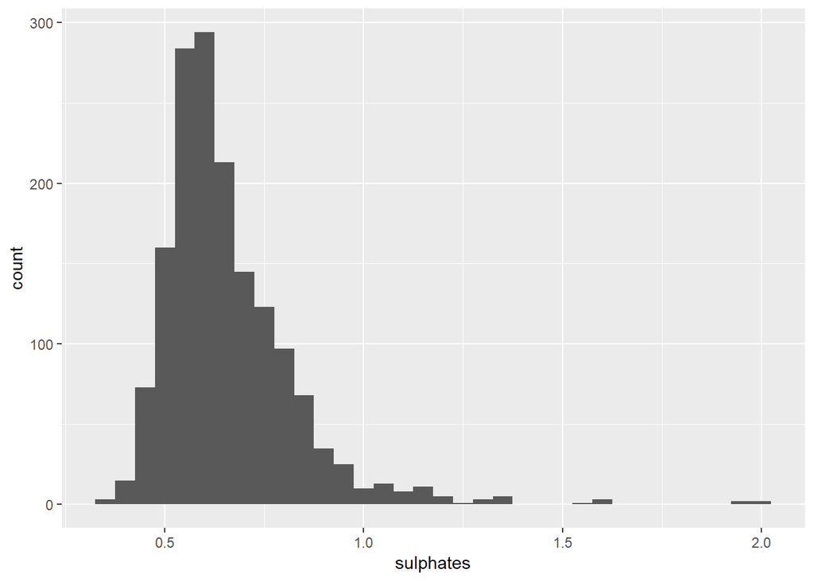

From this histogram we can see that sulphates distribution is right skewed. There are a few outliers close to 2.

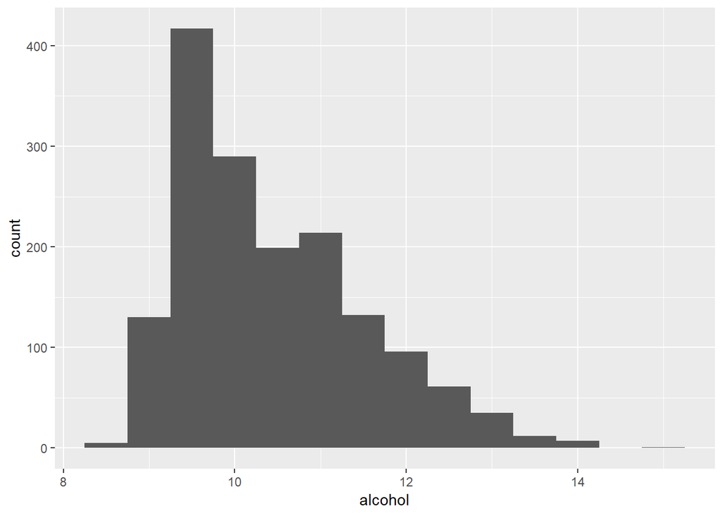

```
##    Min. 1st Qu.  Median    Mean 3rd Qu.    Max.
##    8.40    9.50   10.20   10.42   11.10   14.90
```

The alcohol distribution is again right skewed. The lowest level of alcohol is 8.4 and the highest is 14.9. Most of the wines have alcohol level somewhere between 9.5 and 11.5.

# Univariate Analysis

### What is the structure of your dataset?

There are 1599 red wine observations with 12 variables:

- fixed acidity
- volatile acidity
- citric acid
- residual sugar
- chlorides
- free sulfur dioxide
- total sulfur dioxide
- density
- pH
- sulphates
- alcohol
- quality

All variables have numeric values. Quality is the only categorical variable which has values between 0 (very bad) and 10 (very excellent).

Other observations:

- The citric acid distribution looks multimodal with the biggest pick close to 0 and the other 2 about 0.25 and 0.5.
- The distributions of the fixed acidity, volatile acidity, residual sugar, chlorides, free sulfur dioxide, total sulfur dioxide, sulphates and alcohol are right skewed.
- The distributions of density and pH are normal.
- The quality levels are between 3 and 8. Most of the wines have quality rating of 5 and 6.

### What is/are the main feature(s) of interest in your dataset?

The main feature is quality. I want to see if any of the provided chemical properties correlated with the quality rating.

### What other features in the dataset do you think will help support your investigation into your feature(s) of interest?

So far it is difficult to say which features are going to be correlated with the quality of wine.

### Did you create any new variables from existing variables in the dataset?

I created a factor variable from quality. It will help me in bivariate exploration section.

### Of the features you investigated, were there any unusual distributions? Did you perform any operations on the data to tidy, adjust, or change the form of the data? If so, why did you do this?

I noticed that out of 274 values of citric acid less then 0.05, which fall into the first bin, almost half (132) have value 0. I think they represent missing data and not the actual level of citric acid.

# Bivariate Plots Section

```
##                      fixed.acidity volatile.acidity citric.acid
## fixed.acidity                1.000           -0.256       0.672
## volatile.acidity            -0.256            1.000      -0.552
## citric.acid                  0.672           -0.552       1.000
## residual.sugar               0.115            0.002       0.144
## chlorides                    0.094            0.061       0.204
## free.sulfur.dioxide         -0.154           -0.011      -0.061
## total.sulfur.dioxide        -0.113            0.076       0.036
## density                      0.668            0.022       0.365
## pH                          -0.683            0.235      -0.542
## sulphates                    0.183           -0.261       0.313
## alcohol                     -0.062           -0.202       0.110
## quality                      0.124           -0.391       0.226
##                      residual.sugar chlorides free.sulfur.dioxide
## fixed.acidity                 0.115     0.094              -0.154
## volatile.acidity              0.002     0.061              -0.011
## citric.acid                   0.144     0.204              -0.061
## residual.sugar                1.000     0.056               0.187
## chlorides                     0.056     1.000               0.006
## free.sulfur.dioxide           0.187     0.006               1.000
## total.sulfur.dioxide          0.203     0.047               0.668
## density                       0.355     0.201              -0.022
## pH                           -0.086    -0.265               0.070
## sulphates                     0.006     0.371               0.052
## alcohol                       0.042    -0.221              -0.069
## quality                       0.014    -0.129              -0.051
##                      total.sulfur.dioxide density     pH sulphates alcohol
## fixed.acidity                      -0.113   0.668 -0.683     0.183  -0.062
## volatile.acidity                    0.076   0.022  0.235    -0.261  -0.202
## citric.acid                         0.036   0.365 -0.542     0.313   0.110
## residual.sugar                      0.203   0.355 -0.086     0.006   0.042
## chlorides                           0.047   0.201 -0.265     0.371  -0.221
## free.sulfur.dioxide                 0.668  -0.022  0.070     0.052  -0.069
## total.sulfur.dioxide                1.000   0.071 -0.066     0.043  -0.206
## density                             0.071   1.000 -0.342     0.149  -0.496
## pH                                 -0.066  -0.342  1.000    -0.197   0.206
## sulphates                           0.043   0.149 -0.197     1.000   0.094
## alcohol                            -0.206  -0.496  0.206     0.094   1.000
## quality                            -0.185  -0.175 -0.058     0.251   0.476
##                      quality
## fixed.acidity          0.124
## volatile.acidity      -0.391
## citric.acid            0.226
## residual.sugar         0.014
## chlorides             -0.129
## free.sulfur.dioxide   -0.051
## total.sulfur.dioxide  -0.185
## density               -0.175
## pH                    -0.058
## sulphates              0.251
## alcohol                0.476
## quality                1.000
```

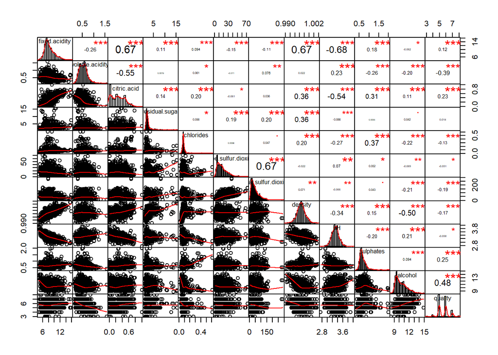

Here we can see that there are no strong correlations between any variables. Some variables moderately correlated. The strongest relationship is between fixed acidity and pH (-0.683). Let’s look closer.

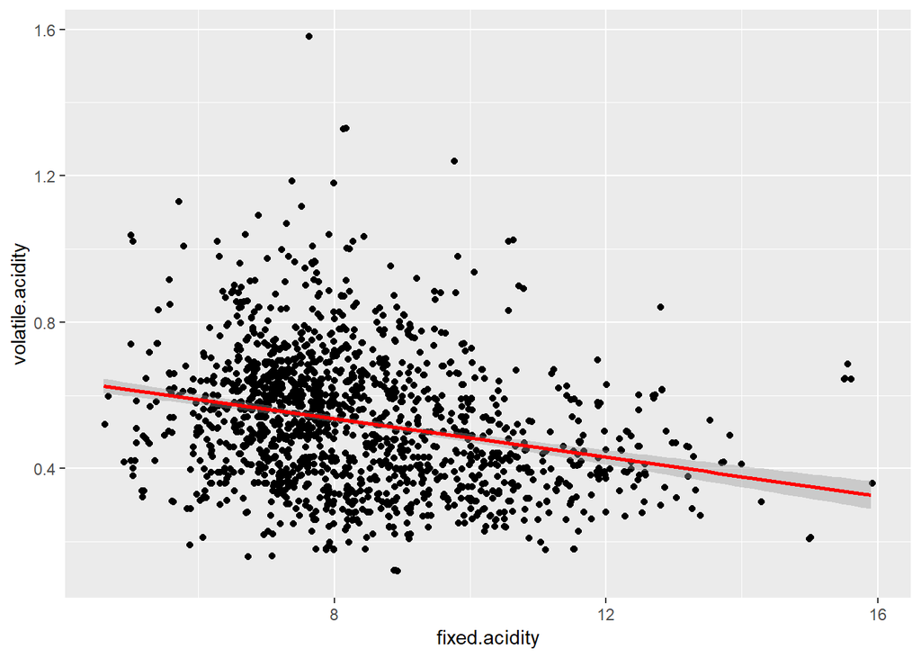

Earlier I was wondering if fixed acidity and volatile acidity are correlated. We can see now that they have weak negative correlation (-0.256). But both of them have moderate correlation with citric acid.

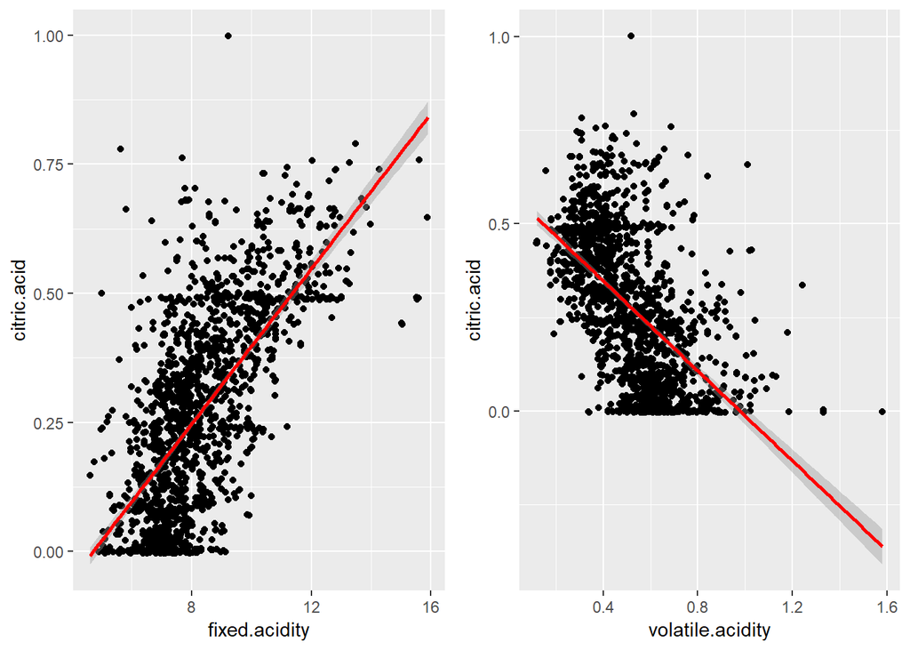

We can see that fixed acidity and citric acid have positive moderate correlation (0.672), and volatile acidity and citric acid have negative moderate correlation (-0.552).

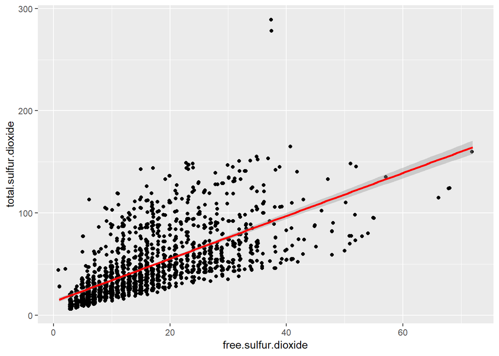

As I expected free sulfur dioxide and total sulfur dioxide have moderate positive correlation (0.668). The higher level of free sulfur dioxide, the higher level of total sulfur dioxide.

Now I want to look what has correlation with quality.

```
##        fixed.acidity     volatile.acidity          citric.acid
##                0.124               -0.391                0.226
##       residual.sugar            chlorides  free.sulfur.dioxide
##                0.014               -0.129               -0.051
## total.sulfur.dioxide              density                   pH
##               -0.185               -0.175               -0.058
##            sulphates              alcohol              quality
##                0.251                0.476                1.000
```

According to these data quality is moderately correlated only with volatile acidity and alcohol. The smallest correlation is with residual sugar.

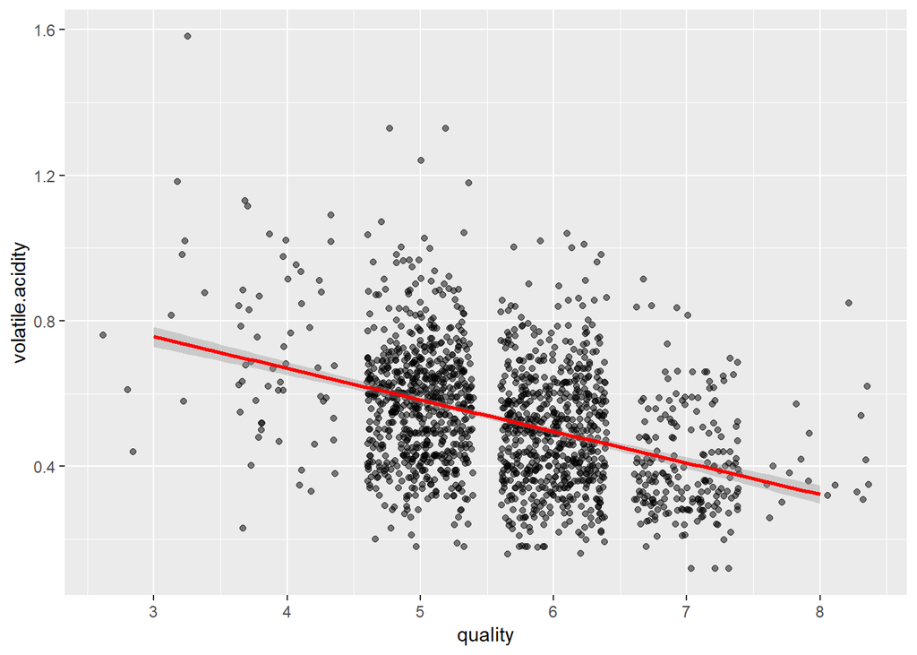

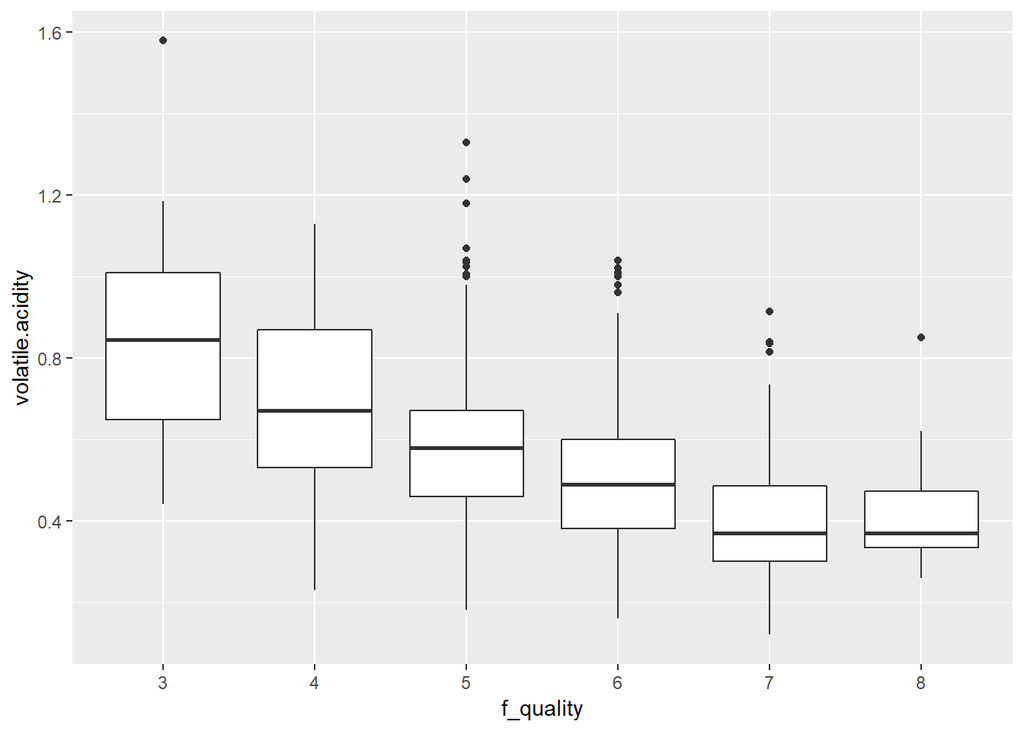

These two plots support the correlation coefficient we got earlier (-0.391). In boxplot we can also see lack of correlation quality rating 7 and 8.

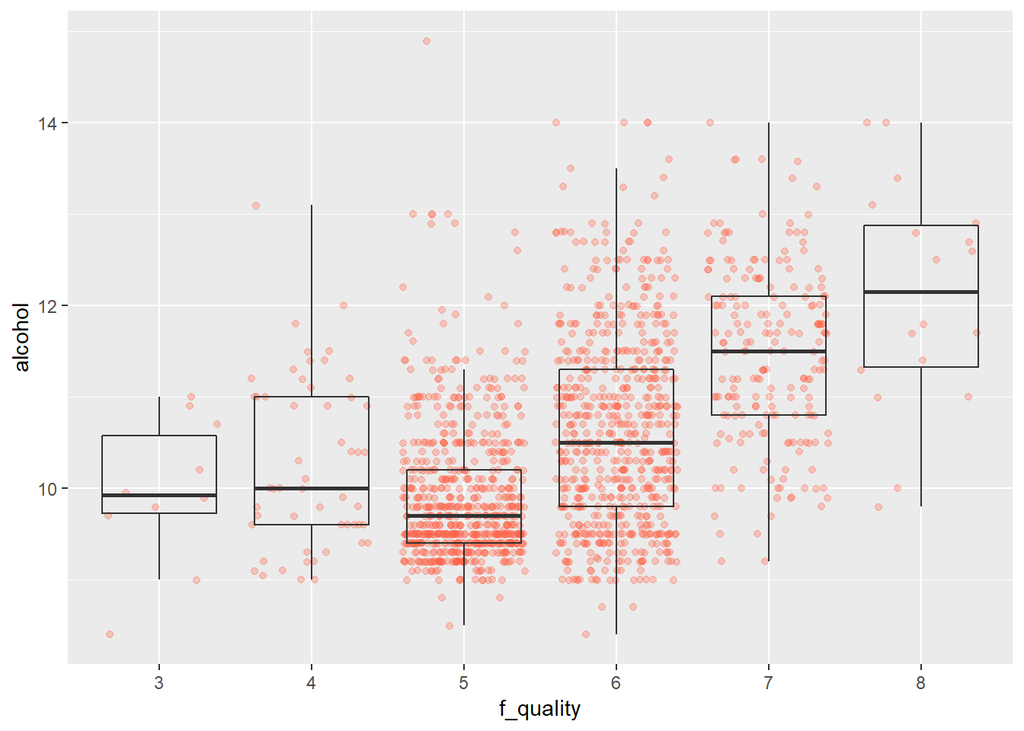

```r
# statistics for alcohol by quality
by(df2$alcohol, df2$quality, summary)
```

```
## df2$quality: 3
##    Min. 1st Qu.  Median    Mean 3rd Qu.    Max.
##   8.400   9.725   9.925   9.955  10.575  11.000
## --------------------------------------------------------
## df2$quality: 4
##    Min. 1st Qu.  Median    Mean 3rd Qu.    Max.
##    9.00    9.60   10.00   10.27   11.00   13.10
## --------------------------------------------------------
## df2$quality: 5
##    Min. 1st Qu.  Median    Mean 3rd Qu.    Max.
##     8.5     9.4     9.7     9.9    10.2    14.9
## --------------------------------------------------------
## df2$quality: 6
##    Min. 1st Qu.  Median    Mean 3rd Qu.    Max.
##    8.40    9.80   10.50   10.63   11.30   14.00
## --------------------------------------------------------
## df2$quality: 7
##    Min. 1st Qu.  Median    Mean 3rd Qu.    Max.
##    9.20   10.80   11.50   11.47   12.10   14.00
## --------------------------------------------------------
## df2$quality: 8
##    Min. 1st Qu.  Median    Mean 3rd Qu.    Max.
##    9.80   11.32   12.15   12.09   12.88   14.00
```

Correlation coefficient for alcohol and quality is 0.476. We can see it on our plot also. But what is interesting, the median alcohol level for quality rate 3 and 4 is actually higher than for quality rate 5.

# Bivariate Analysis

### Talk about some of the relationships you observed in this part of the investigation. How did the feature(s) of interest vary with other features in the dataset?

There are no strong correlations between any variables. Some variables moderately correlated.

Fixed acidity and volatile acidity have moderate correlation with citric acid.

Quality is moderately correlated only with volatile acidity and alcohol.

Even though the correlation between alcohol and quality is positive, the median alcohol level for quality rate 3 and 4 is actually higher than for quality rate 5.

### Did you observe any interesting relationships between the other features (not the main feature(s) of interest)?

As I expected free sulfur dioxide and total sulfur dioxide have moderate positive correlation.

### What was the strongest relationship you found?

The strongest relationship is between fixed acidity and pH (-0.683).

# Multivariate Plots Section

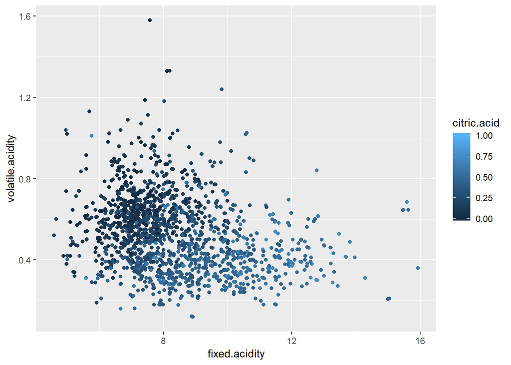

On this scatter plot we can see the same result as earlier. The citric acid is higher for higher values of fixed acidity and lower values of volatile acidity.

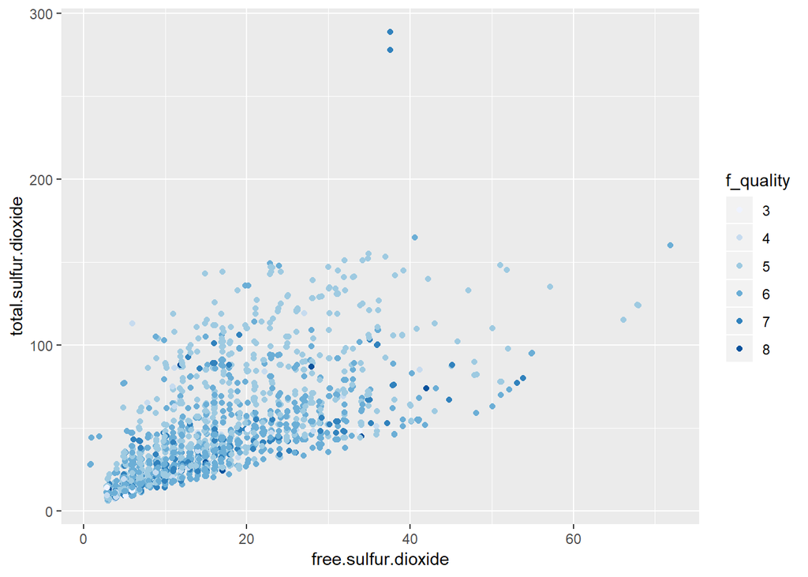

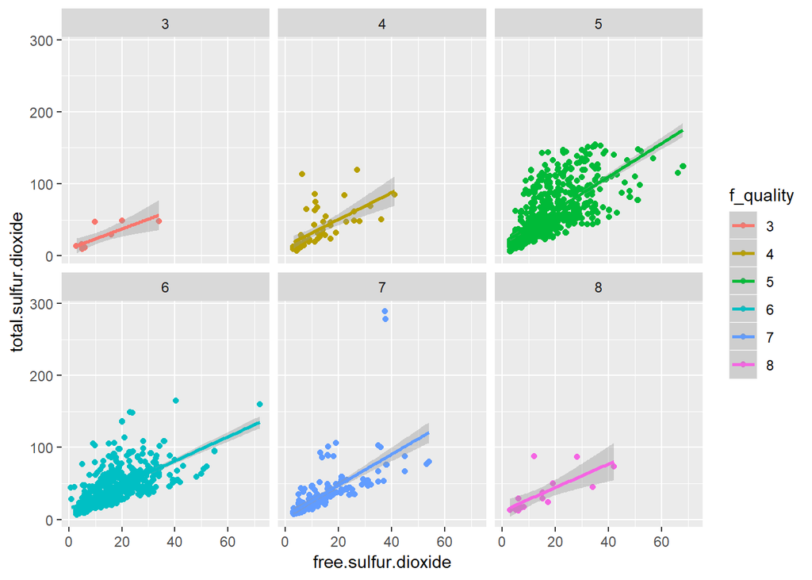

Here we can see lack of correlation between free sulfur dioxide or total sulfur dioxide and quality. For each quality level there is the same pattern of relationship between free sulfur dioxide and total sulfur dioxide.

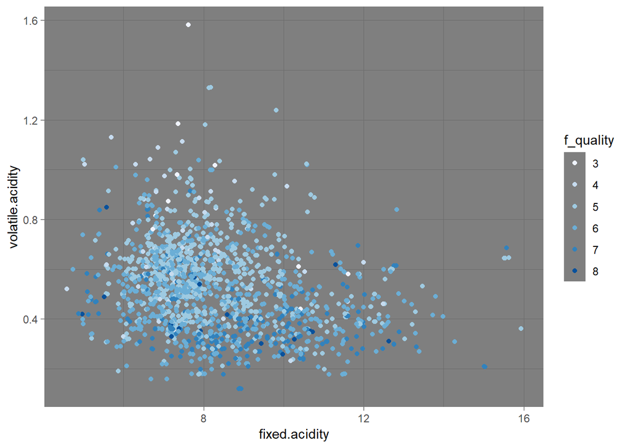

On this plot dark blue points are mostly on the bottom part of plot. That means that there is a negative correlation between volatile acidity and quality, which we had shown earlier. Also we can see a weak negative correlation between fixed acidity and volatile acidity.

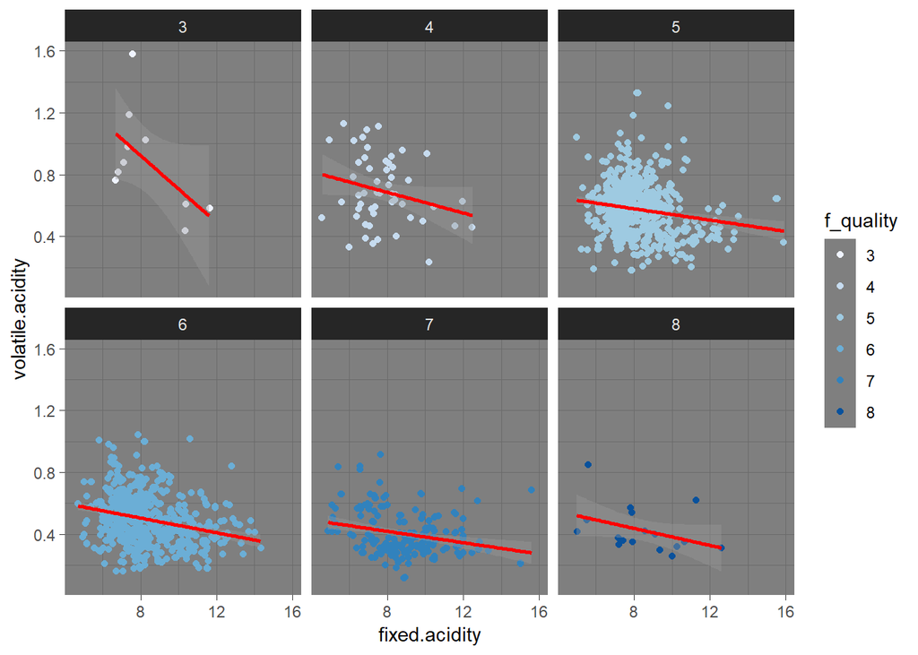

# Multivariate Analysis

### Talk about some of the relationships you observed in this part of the investigation. Were there features that strengthened each other in terms of looking at your feature(s) of interest?

Observations in this part supported earlier conclusions. Citric acid is positively correlated with fixed acidity and negatively correlated with volatile acidity. There is a negative correlation between volatile acidity and quality

### Were there any interesting or surprising interactions between features?

# Final Plots and Summary

### Plot One

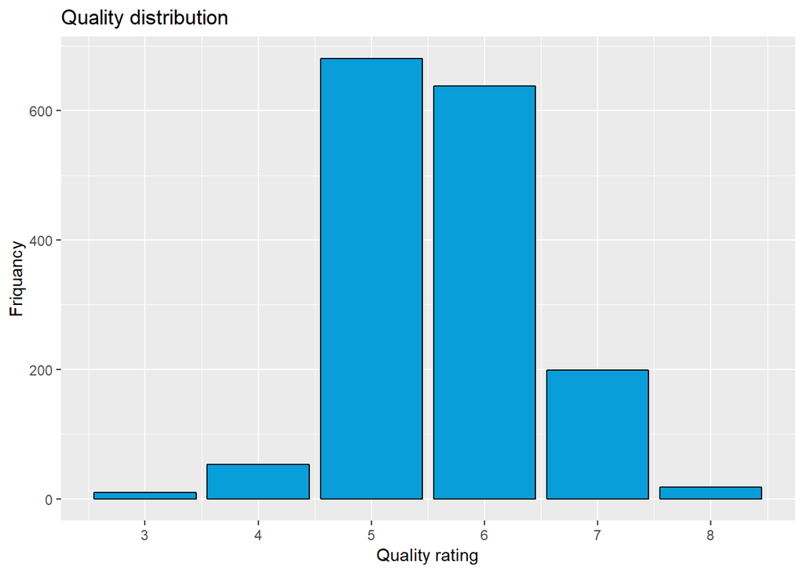

### Description One

From this bar plot we can see, that more than half of the wines in our dataset got quality rating 5 or 6. None of the wines were rated lower than 3 and higher than 8. So we don’t have very excellent wines or very bad wines in the dataset.

### Plot Two

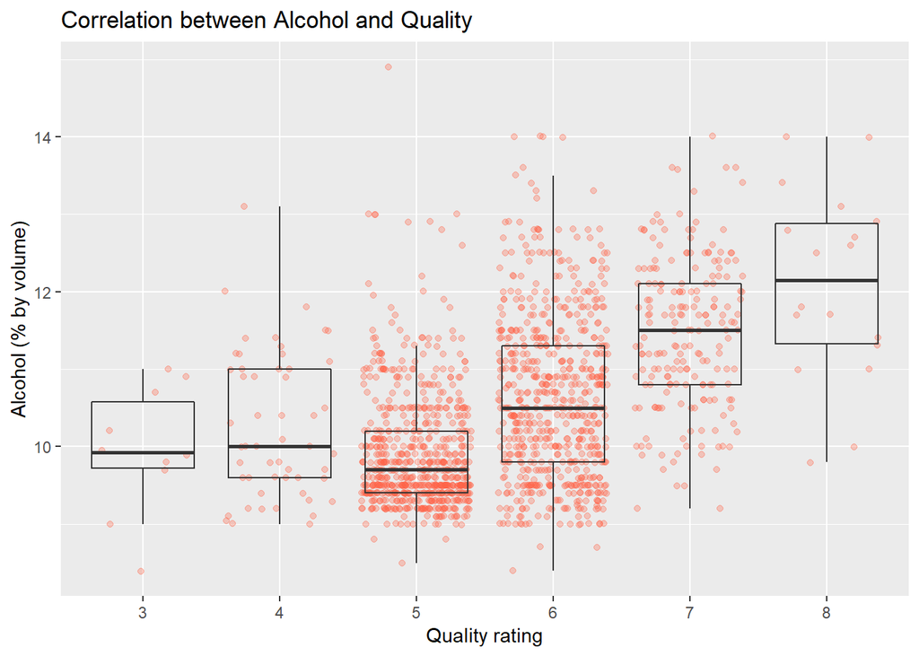

### Description Two

Correlation coefficient for alcohol and quality is 0.476. We can see it on our plot also. But what is interesting, the median alcohol level for quality rate 3 and 4 is actually higher than for quality rate 5.

### Plot Three

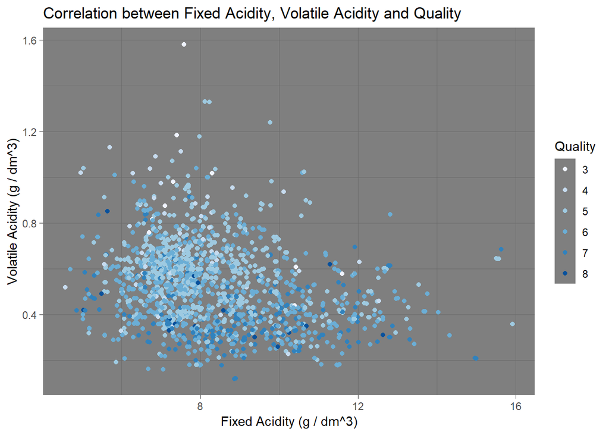

### Description Three

On this plot dark blue points are mostly on the bottom part of plot. That means that there is a negative correlation between volatile acidity and quality. Also we can see a weak negative correlation between fixed acidity and volatile acidity.

# Reflection

Our dataset contains 1,599 observations of red wines with 11 variables on the chemical properties of the wine and 1 variable on quality. At least 3 wine experts rated the quality of each wine, providing a rating between 0 (very bad) and 10 (very excellent). More than half of the wines in our dataset got quality rating 5 or 6. Surprisingly, none of the wines were rated lower than 3 and higher than 8. So we don’t have very excellent wines or very bad wines in the dataset. Quality is moderately correlated only with volatile acidity and alcohol. The smallest correlation is with residual sugar.

I struggled with finding strong correlations between quality of wine and its chemical properties. Also I had problem predicting any correlations based on Univariate Analysis. Maybe it happened because of lack of knowledge in chemistry. In future work I would research more on that topic. After plotting a correlation matrix, I quickly found variables with relationship.